# Full Covariance Regression Applied to HCP Data

Christof Seiler

2017-06-22

## Goal

Apply **full** covariance regression model to preprocessed timeseries data from the [Human Connectome Project](https://db.humanconnectome.org/data/projects/HCP_1200).

```r
library(CovRegFC)
```

```r
library(cowplot)
library(ggplot2)
library(reshape2)
library(magrittr)
library(stringr)
library(devtools)
library(rstan)
library(abind)
library(BatchJobs)
library(reshape2)
library(rethinking)
params
```

```
## $num_regions
## [1] "15"
```

## Load HCP Data

Analysis based on data from the WU-Minn HCP 1200 Subjects Data Release with four complete rfMRI runs (with 100% of collected time points). Load subject information and behavioral measurements.

```r
subject_info = read.csv("HCP_PTN820/sample_info.csv")
subject_info = subject_info[,c(
  "Subject",
  "Age",
  "Gender",
  "Acquisition",
  "PSQI_AmtSleep", # amount of sleep in hours
  "PSQI_Score" # Pittsburgh Sleep Quality Index (PSQI) Completed
  )]
```

Classification of sleep duration from Hirshkowitz et al. (2015)[^1]:

- short sleepers: average equal or less than 6 hours each night
- conventional sleepers: average between 7 and 9 hours each night

```r
sleep_duration = rep("undefined",nrow(subject_info))
sleep_duration[subject_info$PSQI_AmtSleep <= 6] = "short"
sleep_duration[(subject_info$PSQI_AmtSleep >= 7) & (subject_info$PSQI_AmtSleep <= 9)] = "conventional"
subject_info$sleep_duration = factor(sleep_duration)
table(subject_info$sleep_duration)
```

```
##
## conventional        short    undefined
##          710          366          130
```

```r
str(subject_info)
```

```
## 'data.frame':    1206 obs. of  7 variables:
##  $ Subject       : int  100004 100206 100307 100408 100610 101006 101107 101208 101309 101410 ...
##  $ Age           : Factor w/ 4 levels "22-25","26-30",..: 1 2 2 3 2 3 1 3 2 2 ...
##  $ Gender        : Factor w/ 2 levels "F","M": 2 2 1 2 2 1 2 1 2 2 ...
##  $ Acquisition   : Factor w/ 13 levels "Q01","Q02","Q03",..: 6 11 1 3 8 6 6 12 6 6 ...
##  $ PSQI_AmtSleep : num  5 6 6.5 8 7 7 4 7 5.5 5.5 ...
##  $ PSQI_Score    : int  8 6 4 4 4 2 9 6 5 8 ...
##  $ sleep_duration: Factor w/ 3 levels "conventional",..: 2 2 3 1 1 1 2 1 2 2 ...
```

Load timeseries.

```r
num_regions = as.integer(params$num_regions)
num_regions
```

```
## [1] 15
```

```r
channel_names = paste0("R",1:num_regions)
path = paste0("HCP_PTN820/node_timeseries/3T_HCP820_MSMAll_d",num_regions,"_ts2")
file_names = list.files(path = path,pattern = ".txt")
file_subject_ids = strsplit(file_names,split = ".txt") %>% unlist
ts = lapply(file_subject_ids,function(Subject) {
  print(paste("reading subject:",Subject))
  full_path = paste0(path,"/",Subject,".txt")
  timeseries = read.csv(full_path,header = FALSE,sep = " ")
  timeseries$Subject = Subject
  timeseries
}) %>% do.call(rbind,.) %>% data.frame
```

[output not shown]

[output cut: 805 more lines]

```r
names(ts)[1:num_regions] = channel_names
```

Merge timeseries and subject info into one data frame.

```r
ts_subject_info = merge(ts,subject_info,by = "Subject")
```

Plot timeseries for subject `100206`.

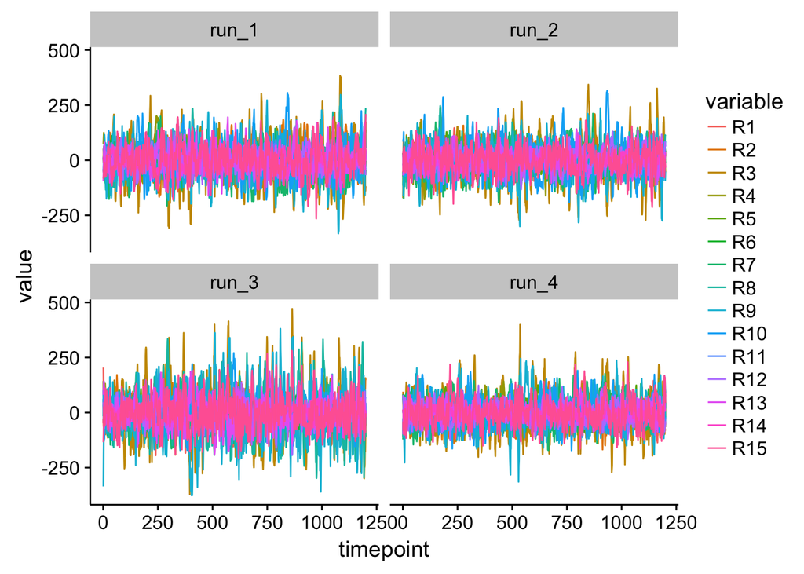

```r
timeseries = subset(ts_subject_info,Subject == 100206)
timeseries$timepoint = rep(1:(nrow(timeseries)/4),4)
timeseries$run = lapply(paste0("run_",1:4),function(i) rep(i,nrow(timeseries)/4)) %>% unlist
timeseries_long = melt(timeseries,id.vars = c("timepoint","run",names(subject_info)))
ggplot(timeseries_long,aes(x = timepoint,y = value,color = variable)) +
  geom_line() + facet_wrap(~run)
```

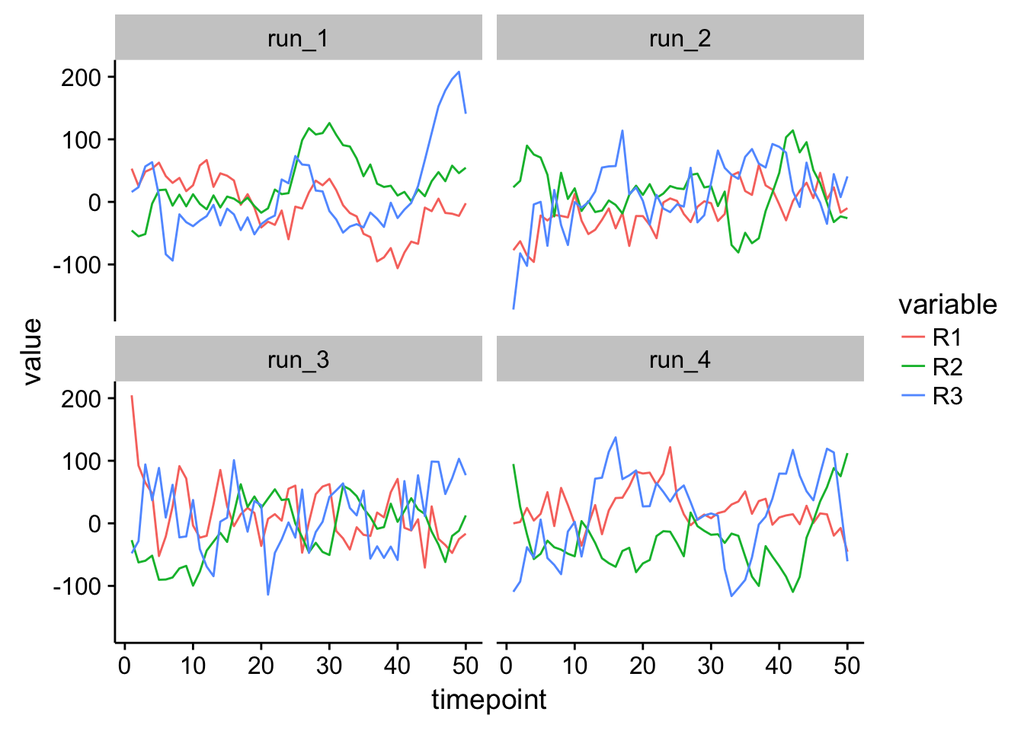

```r
timeseries_long_subset = subset(timeseries_long,
                                timepoint < 51 & (variable == "R1" | variable == "R2" | variable == "R3"))
ggplot(timeseries_long_subset,aes(x = timepoint,y = value,color = variable)) +
  geom_line() + facet_wrap(~run)
```

```r
# set.seed(934321)
# ts_subject_info = subset(ts_subject_info,sleep_duration == "short" | sleep_duration == "conventional")
# subsample_size = 20
# sampled_subjects = sample(names(table(ts_subject_info$Subject)),size = subsample_size)
# ts_subject_info_subset = subset(ts_subject_info,Subject %in% sampled_subjects) %>% droplevels
# str(ts_subject_info_subset)
# table(ts_subject_info_subset$Subject)
# table(ts_subject_info_subset$sleep_duration)/table(ts_subject_info_subset$Subject)[1]
```

Compute average covariance matrices per task/condition.

```r
subset_tasks = function(data,factor_name,level_name) {
  data_subgroup = data[which(data[factor_name] == level_name),] %>% droplevels
  region_ids = str_detect(names(ts_subject_info),"R") %>% which
  subject_ids = table(data_subgroup$Subject) %>% names
  scov = list()
  K = length(subject_ids)
  P = length(region_ids)
  scov$YY = array(dim = c(K,P,P))
  for(i in 1:K) {
    Y = subset(data_subgroup,Subject == subject_ids[i])[,region_ids]
    Y_c = scale(Y,center = TRUE,scale = FALSE)
    scov$YY[i,,] = t(Y_c) %*% Y_c
  }
  scov$N = table(data_subgroup$Subject)
  scov
}
#scov_short = subset_tasks(ts_subject_info_subset,"sleep_duration","short")
scov_short = subset_tasks(ts_subject_info,"sleep_duration","short")
#scov_conventional = subset_tasks(ts_subject_info_subset,"sleep_duration","conventional")
scov_conventional = subset_tasks(ts_subject_info,"sleep_duration","conventional")
```

Plot average covariance matrices per task/condition.

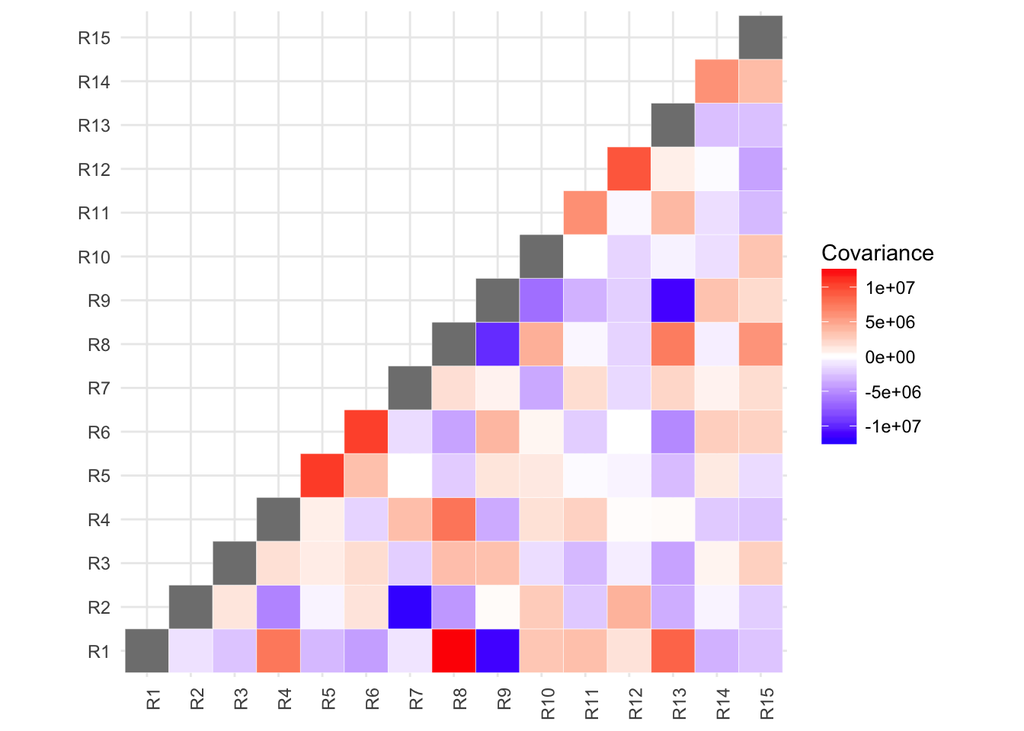

```r
plot_cov = function(YY,limit_value) {
  rownames(YY) = colnames(YY) = channel_names
  get_upper_tri = function(mat) {
    mat[lower.tri(mat)] = NA
    mat
  }
  YY_long = melt(get_upper_tri(YY), na.rm = TRUE)
  ggplot(data = YY_long, aes(Var2, Var1, fill = value)) +
    geom_tile(color = "white") +
    scale_fill_gradient2(low = "blue", high = "red", mid = "white",
                         midpoint = 0, space = "Lab",
                         limit = c(-limit_value,limit_value),
                         name = "Covariance") +
    theme_minimal() +
    theme(axis.text.x = element_text(angle = 90, vjust = 1, hjust = 1),
          axis.title.x=element_blank(),
          axis.title.y=element_blank(),
          legend.position="right") +
    coord_fixed()
}
scov_short_mean = apply(scov_short$YY,MARGIN = c(2,3),FUN = mean)
scov_conventional_mean = apply(scov_conventional$YY,MARGIN = c(2,3),FUN = mean)
limit_value = max(abs(c(scov_short_mean[lower.tri(scov_short_mean)] %>% abs %>% max,
                        scov_conventional_mean[lower.tri(scov_conventional_mean)] %>% abs %>% max)))
plot_cov(scov_short_mean,limit_value)
```

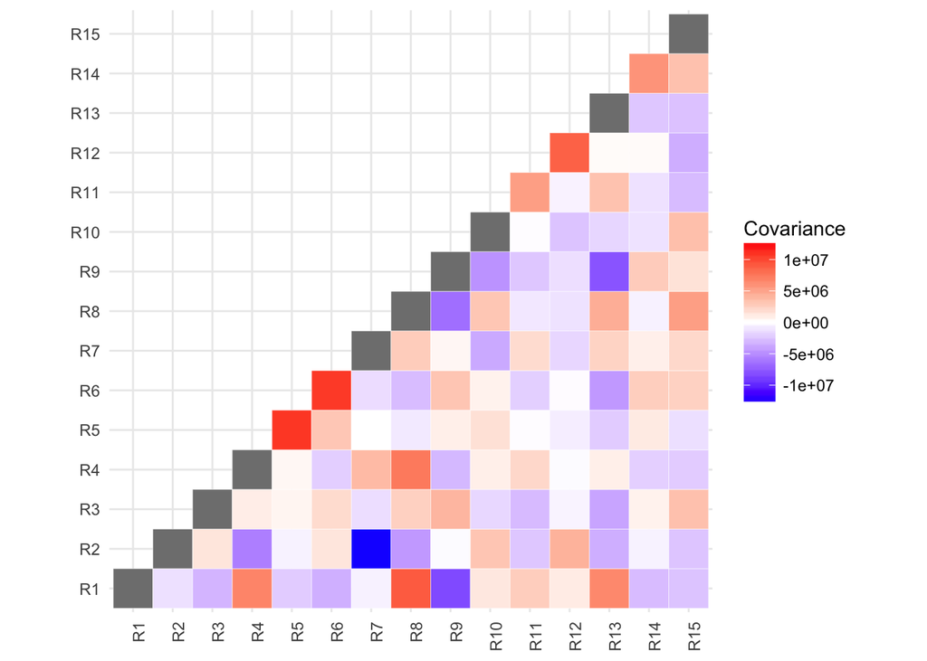

```r
plot_cov(scov_conventional_mean,limit_value)
```

## Full Covariance Modeling

```r
YY = abind(scov_conventional$YY,scov_short$YY,along = 1)
N = min(scov_conventional$N,scov_short$N)
short = c(rep(0,length(scov_conventional$N)),rep(1,length(scov_short$N)))
X = data.frame(intercept=rep(1,length(short)),short)
# run it in batch mode
log_name = paste0("HCP_full_",num_regions)
if(dir.exists(log_name)) unlink(log_name,recursive = TRUE) # cleanup
reg = makeRegistry(id = log_name, file.dir = log_name)
```

```
## Creating dir: HCP_full_15
```

```
## Saving registry: /Users/cseiler/CovRegFC_HCP/HCP_full_15/registry.RData
```

```r
batchExport(reg, li = list(YY = YY,
                           X = X,
                           N = N,
                           scov_short_mean = scov_short_mean,
                           scov_conventional_mean = scov_conventional_mean),
            overwrite = TRUE)
fun = function(seed) {
  library(CovRegFC)
  CovRegFC::covreg_full(YY = YY,
                        X = X,
                        N = N,
                        scov_short_mean = scov_short_mean,
                        scov_conventional_mean = scov_conventional_mean,
                        seed = seed)
}
batchMap(reg, fun, 15324)
```

```
## Adding 1 jobs to DB.
```

```r
submitJobs(reg)
```

```
## Saving conf: /Users/cseiler/CovRegFC_HCP/HCP_full_15/conf.RData
```

```
## Submitting 1 chunks / 1 jobs.
```

```
## Cluster functions: Interactive.
```

```
## Auto-mailer settings: start=none, done=none, error=none.
```

```
## Loading registry: /Users/cseiler/CovRegFC_HCP/HCP_full_15/registry.RData
```

```
## Loading RData files: N,scov_conventional_mean,scov_short_mean,X,YY
```

```
## Loading conf: /Users/cseiler/CovRegFC_HCP/HCP_full_15/conf.RData
```

```
## 2017-06-22 17:11:33: Starting job on node Christofs-MacBook-Pro-2.local.
```

```
## Auto-mailer settings: start=none, done=none, error=none.
```

```
## Setting work dir: /Users/cseiler/CovRegFC_HCP
```

```
## Loading jobs from file '/Users/cseiler/CovRegFC_HCP/HCP_full_15/jobs/01/1.rds'
```

```
## ########## Executing jid=1 ##########
```

```
## Timestamp: 2017-06-22 17:11:33
```

```
## Setting seed: 281998234
```

```
## Writing result file: /Users/cseiler/CovRegFC_HCP/HCP_full_15/jobs/01/1-result.RData
```

```
## 2017-06-22 18:19:13: All done.
```

```
## Setting work back to: /Users/cseiler/CovRegFC_HCP
```

```
## Memory usage according to gc:
```

```
## Sending 1 submit messages...
## Might take some time, do not interrupt this!
```

```r
waitForJobs(reg,sleep = 360)
```

```
## Syncing registry ...
```

```
## [1] TRUE
```

```r
res_list = reduceResultsList(reg)
```

```
## Reducing 1 results...
```

```r
fit = res_list[[1]]
save(fit,file = paste0("fit_full_",num_regions,".Rdata"))
```

Convergence diagnostics.

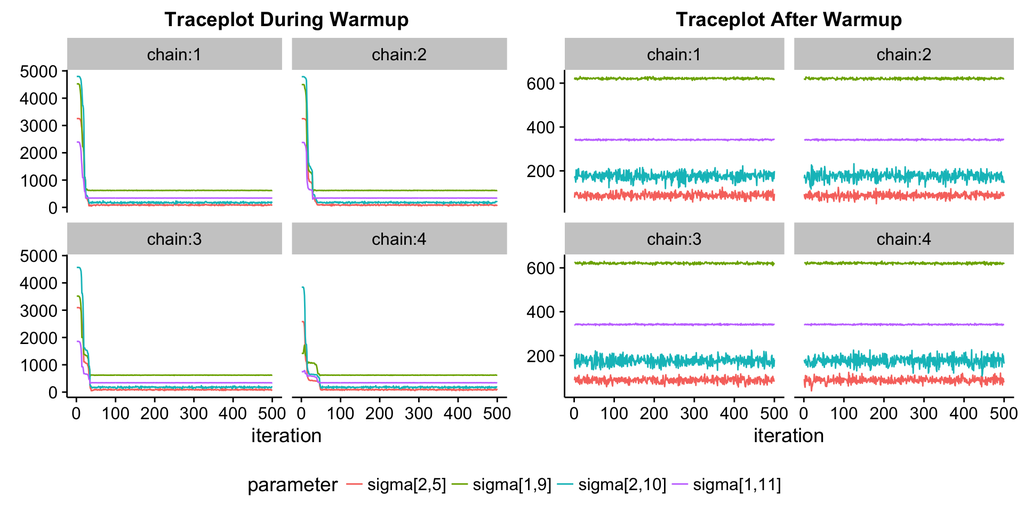

```r
CovRegFC::plot_diagnostics(fit,"sigma",num_par = 4)
```

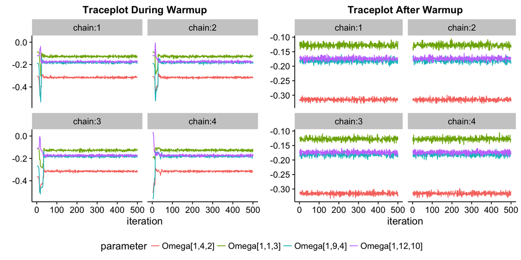

```r
CovRegFC::plot_diagnostics(fit,"Omega",num_par = 4)
```

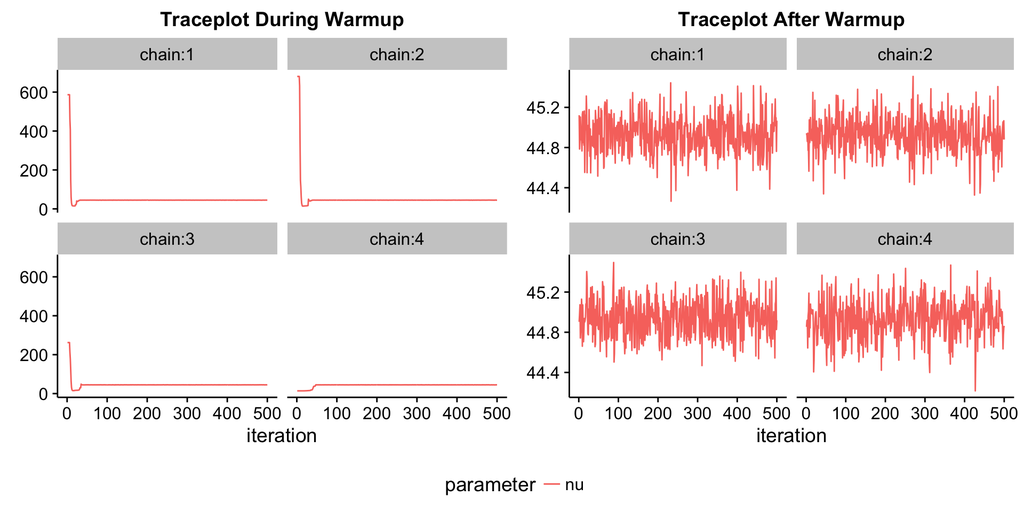

```r
CovRegFC::plot_diagnostics(fit,"nu",num_par = 4)
```

Plot differential correlation.

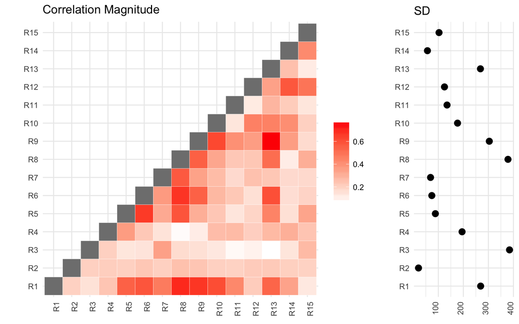

```r
p_cov_da = CovRegFC::plot_post_mean(fit,channel_names)
p_cov_da
```

```r
ggsave(p_cov_da,filename = paste0("cov_short_vs_conventional_",num_regions,".pdf"),height = 4,width = 6)
```

Differential analysis: shorter correlation stronger than conventional sleep duration correlations?

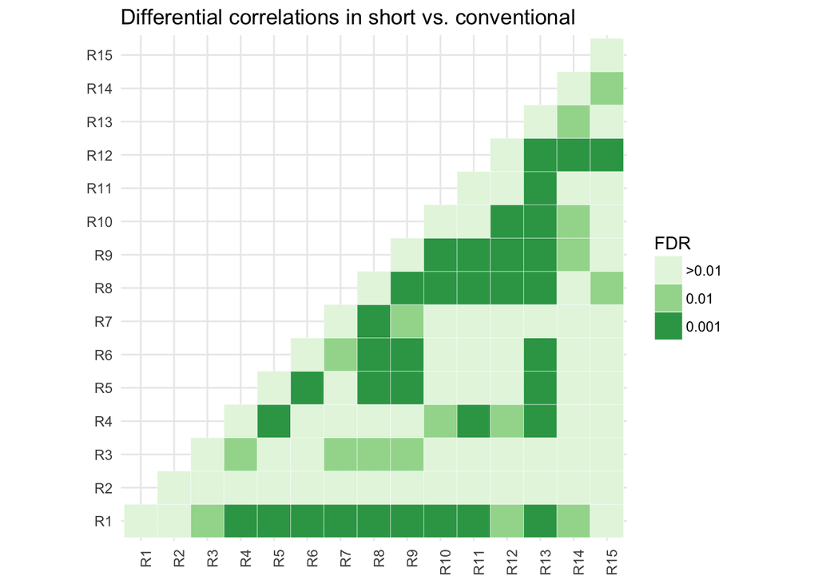

```r
CovRegFC::plot_corr_da(fit,channel_names,"Differential correlations in short vs. conventional")
```

```r
ggsave(filename = paste0("full_connectivity_",num_regions,".pdf"),height = 4,width = 5)
```

## Simulations from Correlation Matrix Prior

Distribution of $1000$ off-diagonal elements $R_{12}$ extracted from correlation matrix drawn from LKJ prior.

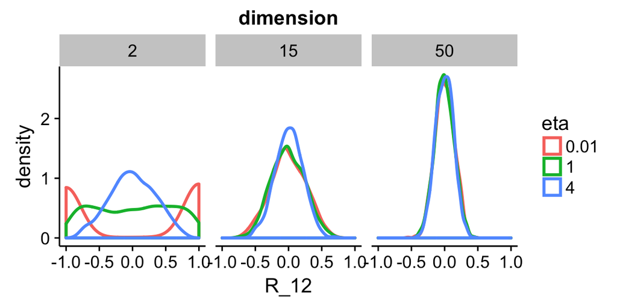

```
##  setting  value
##  version  R version 3.3.2 (2016-10-31)
##  system   x86_64, darwin13.4.0
##  ui       X11
##  language (EN)
##  collate  en_US.UTF-8
##  tz       America/Los_Angeles
##  date     2017-06-22
```

```
## Packages -----------------------------------------------------------------
```

[output not shown]

[output cut: 79 more lines]

[output not shown]

[^1]: Hirshkowitz et al. (2015), National Sleep Foundation’s sleep recommendations: Methodology and results summary, Sleep Health.